# Cluster Analysis

WDI Indicators

امین رخشا ۹۵۱۰۹۳۱۵

2018-07-20 22:26:11

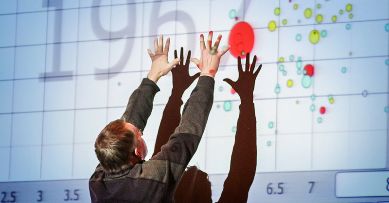

> با توجه به داده بانک جهانی به سوالات زیر پاسخ دهید. برای استفاده از داده از سه فایل زیر استفاده نمایید. داده نام کشورها: WDICountry داده نام سری های زمانی: WDISeries داده کل: WDIData در صورتی که داده را در اختیار ندارید می توانید از بسته WDI استفاده نموده و داده های مورد نظر را استخراج نمایید.

کارهای اولیه

```r
library(stringr)
library(readr)
library(tidyr)
library(highcharter)
library(ggplot2)
library(ggthemes)
library(WDI)
library(countrycode)
library(ggpubr)
library(ggbiplot)
library(dplyr)
library(knitr)

theme_set(theme_minimal() + theme(legend.position = "bottom"))

setwd('/Users/aminrakhsha/Documents/University/Term4 - 97spring/Data Analysis/HW/HW10')
series = read_csv('data/WDISeries.csv')
countryNames = read_csv('data/WDICountry.csv')
data = read_csv('data/WDIData.csv')
set.seed(100)
```

۱. ده کشور فقیر دنیا را بیابید. نمودار درآمد روزانه آنها را رسم کنید. چند درصد از اعضای این کشورها زیر خط فقر هستند؟ متوسط عمر در این کشورها چقدر است؟

از درآمد سرانه‌ی داخلی برای محاسبه‌ی فقیرترین کشورها استفاده می‌کنیم. با توجه به در دسترس نبودن شاخص‌های امید به زندگی و خط فقر در آخرین سال، برای هر کشور آخرین داده‌ای که از آن موجود است را استفاده می‌کنیم.

```r
poorestCountries = data %>%
  filter(`Indicator Code` == 'NY.GDP.PCAP.PP.CD') %>%
  select(`Country Name`, `Country Code`, GDP = `2016`) %>%
  arrange(GDP) %>%
  top_n(10, -GDP) %>%
  mutate(GDP = round(GDP))

PHR = data %>%
  select(-X63) %>%
  filter(`Indicator Code` == 'SI.POV.LMIC') %>%
  gather("year", "value", `1960`:`2017`) %>%
  drop_na() %>%
  mutate(year = as.numeric(year)) %>%
  arrange(year) %>%
  group_by(`Country Name`, `Indicator Code`) %>%
  summarise(lastValue = last(value)) %>%
  spread("Indicator Code", "lastValue") %>%
  rename(PHR = `SI.POV.LMIC`) %>%
  drop_na()


LE = data %>%
  select(-X63) %>%
  filter(`Indicator Code` == 'SP.DYN.LE00.IN') %>%
  gather("year", "value", `1960`:`2017`) %>%
  drop_na() %>%
  mutate(year = as.numeric(year)) %>%
  arrange(year) %>%
  group_by(`Country Name`, `Indicator Code`) %>%
  summarise(lastValue = last(value)) %>%
  spread("Indicator Code", "lastValue") %>%
  rename(LE = `SP.DYN.LE00.IN`) %>%
  drop_na()



poorestCountries = poorestCountries %>%
  left_join(PHR) %>%
  left_join(LE)

poorestCountries %>%
  hchart(type = 'column', hcaes(x = `Country Name`, y = GDP), name = 'GDP per capita') %>%
  hc_yAxis(title = list(text = "GDP per capita")) %>%
  hc_xAxis(title = list(text = "")) %>%
  hc_title(text = "Poorest Countries")
```

[interactive chart not shown]

```r
poorestCountries %>%
  hchart(type = 'column', hcaes(x = `Country Name`, y = PHR), name = 'Poverty gap') %>%
  hc_yAxis(title = list(text = "Poverty gap at $5.50 a day")) %>%
  hc_xAxis(title = list(text = "")) %>%
  hc_title(text = "Poverty gap of Poorest Countries")
```

[interactive chart not shown]

```r
poorestCountries %>%
  hchart(type = 'column', hcaes(x = `Country Name`, y = LE), name = 'Life Expectancy') %>%
  hc_yAxis(title = list(text = "Life Expectancy")) %>%
  hc_xAxis(title = list(text = "")) %>%
  hc_title(text = "Life Expectancy of Poorest Countries")
```

[interactive chart not shown]

۲. تراژدی روآندا: بر اساس داده های امید به زندگی ابتدا نمودار سالانه نمودار جعبه ایی امید به زندگی کشورها را رسم نمایید(در یک نمودار!). سپس سری زمانی امید به زندگی روآندا را به آن اضافه کنید. چه می بینید؟ چند میلیون نفر کشته شدند؟

نمودار کل کشورها و این نمودار به همراه سری زمانی امید به زندگی در رواندا را در زیر می‌بینید. در این تراژدی ۵۰۰ هزار تا یک میلیون نفر کشته شدند.

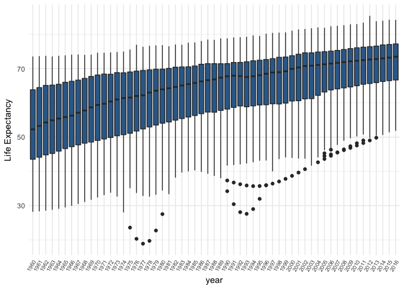

```r
Life.Expectancy = data %>%
  filter(`Indicator Code` == 'SP.DYN.LE00.IN') %>%
  select(-`Indicator Name`, -`Indicator Code`, -X63) %>%
  gather('year', 'LE', `1960`:`2016`)

ggplot(Life.Expectancy, aes(x = year, y = LE, fill = 1)) +
  geom_boxplot() +
  theme(axis.text.x = element_text(angle = 60, hjust = 1, size = 7)) +
  labs(y = 'Life Expectancy') +
  guides(fill = F)
```

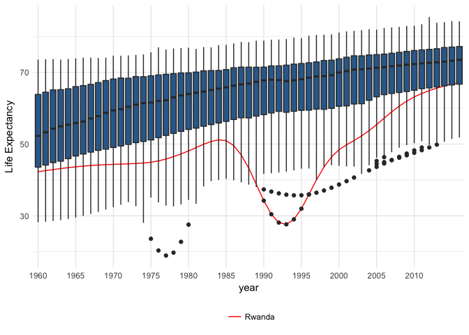

```r
Rwanda.LE = Life.Expectancy %>%
  filter(`Country Name`== 'Rwanda')

ggplot() +
  geom_line(data = Rwanda.LE, aes(x = year, y = LE, group = 1, color = 'red')) +
  geom_boxplot(data = Life.Expectancy,
               aes(x = Life.Expectancy$year, y = Life.Expectancy$LE, fill = 1)) +
  labs(y = 'Life Expectancy') +
  scale_color_manual(labels = 'Rwanda', values = 'red') +
  guides(fill = F) +
  theme(legend.title=element_blank()) +
  theme(legend.position="bottom") +
  scale_x_discrete(breaks = seq(1960, 2010, by = 5))
```

۳. نمودار امید به زندگی و هزینه های بهداشتی را رسم کنید. چه نتیجه ایی می گیرید؟

همانطور که میبینیم در کشورهایی که هزینه‌ها بالاتر است امید به زندگی نیز بیشتر هست. اما این ارتباط خطی نیست و با بالا رفتن هزینه میزان افزایش امید به زندگی کاهش می‌یابد. در حقیقت همانطور که در نمودار میبینید تا حدی امید به زندگی با لگاریتم هزینه‌ها رابطه دارد.

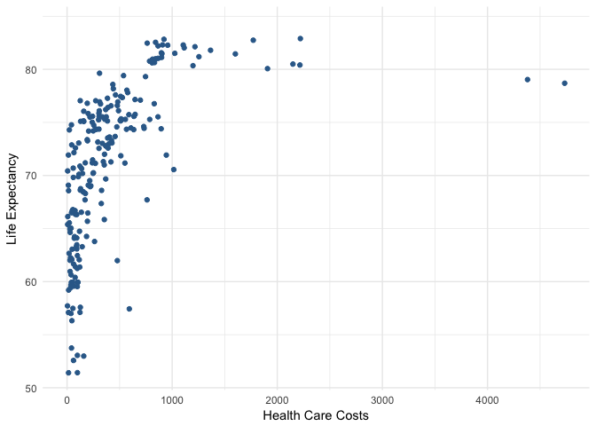

```r
LE.HCC = data %>%
  filter(`Indicator Code` %in% c('SH.XPD.PVTD.PP.CD', 'SP.DYN.LE00.IN')) %>%
  select(`Country Name`, `Country Code`, `2015`, `Indicator Code`) %>%
  spread(key = "Indicator Code", value = "2015") %>%
  rename(HCC = `SH.XPD.PVTD.PP.CD`, LE = `SP.DYN.LE00.IN`)

ggplot(LE.HCC, aes(x = HCC, y = LE)) +
  geom_point(aes(color = 1)) +
  guides(color = F) +
  labs(x = "Health Care Costs", y = "Life Expectancy")
```

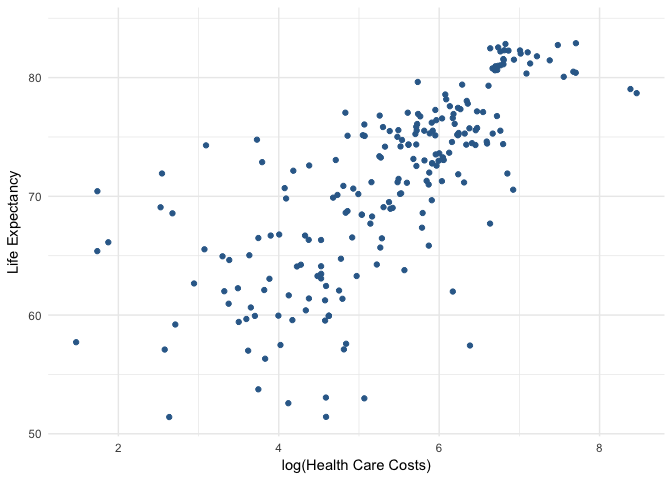

```r
ggplot(LE.HCC, aes(x = log(HCC), y = LE)) +
  geom_point(aes(color = 1)) +
  guides(color = F) +
  labs(x = "log(Health Care Costs)", y = "Life Expectancy")
```

۴. آیا قدرت خرید خانواده های ایرانی در ۵۰ سال اخیر افزایش یافته است؟ برای این کار از داده های اقتصادی خانوار استفاده کنید.

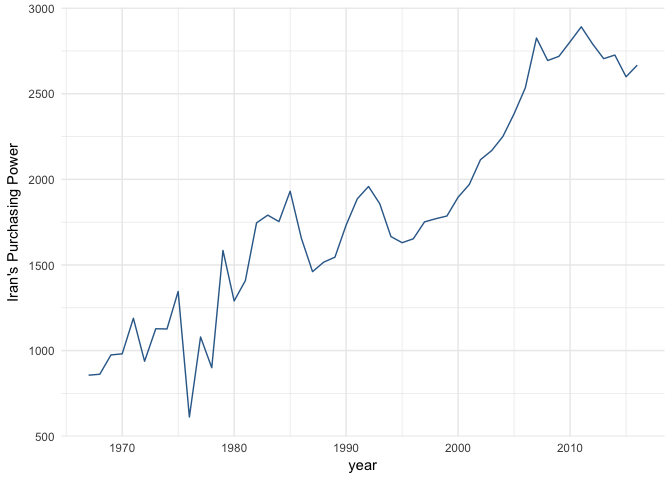

```r
Iran.PP = data %>%
  filter(`Country Code` == 'IRN', `Indicator Code` == 'NE.CON.PRVT.PC.KD') %>%
  gather(key = "year", value = "PP", `1967`:`2016`) %>%
  select(year, PP) %>%
  mutate(year = as.numeric(year))

ggplot(Iran.PP, aes(x = year, y = PP, group = 1, color = 1)) +
  geom_line() +
  guides(color = F) +
  labs(y = "Iran's Purchasing Power")
```

```r
cor.test(Iran.PP$year, Iran.PP$PP, method = 'spearman')
```

```
##
##  Spearman's rank correlation rho
##
## data:  Iran.PP$year and Iran.PP$PP
## S = 1532, p-value < 2.2e-16
## alternative hypothesis: true rho is not equal to 0
## sample estimates:
##       rho
## 0.9264346
```

۵. رشد اقتصادی ایران را با کشورهای دیگر در طول ۲۰ سال گذشته بر حسب بیست شاخص های اقتصادی مهم مانند تولید ناخالص ملی، تورم و … ارزیابی کنید! (برای هر شاخص از تصویرسازی استفاده کنید.)

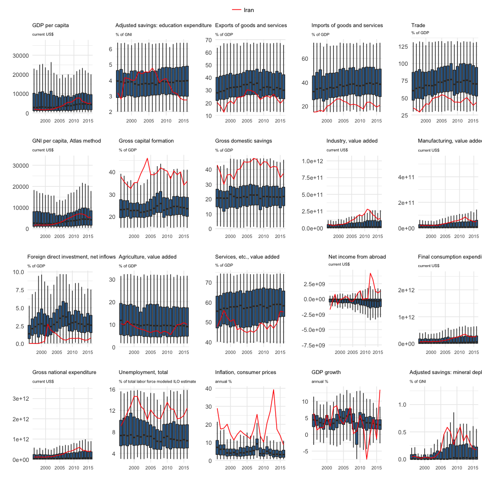

```r
iran.availableIndicators = data %>%
  select(`Country Name`, `Indicator Code`, `Indicator Name`, `1996`:`2015`) %>%
  filter(`Country Name` == "Iran, Islamic Rep.") %>%
  gather(key = "year", value = "value", `1996`:`2015`) %>%
  drop_na() %>%
  group_by(`Indicator Name`, `Indicator Code`) %>%
  summarise(count = n()) %>%
  left_join(series %>% select(`Series Code`, Topic), by = c("Indicator Code" = "Series Code")) %>%
  filter(count >= 20)

availability = data %>%
  select(-X63) %>%
  gather("year", "value", `1960`:`2017`) %>%
  drop_na() %>%
  group_by(`Indicator Code`, `Indicator Name`) %>%
  summarise(count = n()) %>%
  left_join(series %>% select(`Series Code`, Topic, `Long definition`), by = c("Indicator Code" = "Series Code")) %>%
  filter(`Indicator Code` %in% iran.availableIndicators$`Indicator Code`)


availability.economics = availability %>% filter(str_detect(Topic, "Econo"))

economicIndicators = c(
  'NY.GDP.PCAP.CD',
  'NY.ADJ.AEDU.GN.ZS',
  'NE.EXP.GNFS.ZS',
  'NE.IMP.GNFS.ZS',
  'NE.TRD.GNFS.ZS',
  'NY.GNP.PCAP.CD',
  'NE.GDI.TOTL.ZS',
  'NY.GDS.TOTL.ZS',
  'NV.IND.TOTL.CD',
  'NV.IND.MANF.CD',
  'BX.KLT.DINV.WD.GD.ZS',
  'NV.AGR.TOTL.ZS',
  'NV.SRV.TETC.ZS',
  'NY.GSR.NFCY.CD',
  'NE.CON.TETC.CD',
  'NE.DAB.TOTL.CD',
  'SL.UEM.TOTL.ZS',
  'FP.CPI.TOTL.ZG',
  'NY.GDP.MKTP.KD.ZG',
  'NY.ADJ.DMIN.GN.ZS'
)


selectedSeries = series %>% filter(`Series Code` %in% economicIndicators)


plots = list()
for(i in 1:length(economicIndicators)) {
  code = economicIndicators[i]
  name = series %>% filter(`Series Code` == code) %>%
    .$`Indicator Name` %>%
    str_extract("^[^\\(]*(?=\\()")
  sub = series %>% filter(`Series Code` == code) %>%
    .$`Indicator Name` %>%
    str_extract("\\(.*$") %>%
    str_replace_all("\\(", "") %>%
    str_replace_all("\\)", "")

  plotData = data %>%
    filter(`Indicator Code` == code) %>%
    select(-`Indicator Name`, -`Indicator Code`, -X63) %>%
    gather('year', 'value', `1960`:`2016`) %>%
    filter(year >= 1996)

  iranData = plotData %>%
    filter(`Country Name`== 'Iran, Islamic Rep.')

  yLimits = numeric(2)
  yLimits[1] = min(quantile(plotData$value, c(0.1, 0.9), na.rm = T)[1], min(iranData$value))
  yLimits[2] = max(quantile(plotData$value, c(0.1, 0.9), na.rm = T)[2], max(iranData$value))

  plots[[i]] = ggplot() +
    geom_boxplot(data = plotData, aes(x = year, y = value, fill = 1), outlier.shape = NA) +
    geom_line(data= iranData, aes(x = year, y = value, group = 1, color = "red")) +
    ylim(yLimits) +
    labs(title = name, y = "", x = "", subtitle = sub) +
    scale_color_manual(labels = 'Iran', values = 'red') +
    guides(fill = F) +
    theme(legend.title=element_blank()) +
    theme(plot.title = element_text(size=8), plot.subtitle = element_text(size=6)) +
    theme(axis.text.x = element_text(size = 7)) +
    scale_x_discrete(breaks = seq(2000, 2015, by = 5))

}

ggarrange(plotlist = plots, common.legend = T)
```

۶. در قسمت قبل با استفاده از روش خوشه بندی k-means داده ها را به سه دسته تقسیم کنید. ایران در کدام دسته می گنجد؟ (پیش از خوشه بندی طبیعتا داده را باید پاکسازی و استاندارد سازی نمایید.)

نتایج در زیر آمده‌اند. خوشه‌ی یک کشورهای جهان سومی و توسعه نیافته اند. خوشه‌ی ۲ تقریبا پیشرفته ترین کشورها با مهم‌ترین اقتصادها هستند و خوشه‌ی ۳ هم کشورهای پیشرفته‌ی دیگر هستند.

```r
recentData = data %>% select(-X63) %>% filter(`Indicator Code` %in%
    economicIndicators) %>% gather("year", "value", `1960`:`2017`) %>%
    drop_na() %>% mutate(year = as.numeric(year)) %>% arrange(year) %>%
    group_by(`Country Name`, `Indicator Name`) %>% summarise(lastValue = last(value)) %>%
    spread("Indicator Name", "lastValue") %>% drop_na()

numericData = recentData[, -1] %>% scale()
kcl = kmeans(numericData, centers = 3)
eco.clus.results = data.frame(country = recentData$`Country Name`,
    cluster = kcl$cluster, stringsAsFactors = F)

for (i in 1:3) {
    clusterCountries = eco.clus.results %>% filter(cluster ==
        i) %>% .$country
    cat("\n\nCluster No.", i, ":\n")
    cat(clusterCountries, sep = ", ")
}
```

```
##
##
## Cluster No. 1 :
## Afghanistan, Albania, Algeria, Angola, Armenia, Azerbaijan, Bangladesh, Benin, Bhutan, Bolivia, Burkina Faso, Burundi, Cambodia, Cameroon, Central African Republic, Chad, Colombia, Congo, Dem. Rep., Congo, Rep., Cote d'Ivoire, Dominican Republic, Ecuador, Egypt, Arab Rep., El Salvador, Ethiopia, …
##
## Cluster No. 2 :
## China, Germany, Hong Kong SAR, China, Hungary, Ireland, Japan, Luxembourg, Malta, Netherlands, Singapore, Switzerland, United States
##
## Cluster No. 3 :
## Argentina, Australia, Austria, Bahamas, The, Bahrain, Barbados, Belarus, Belgium, Belize, Botswana, Brazil, Brunei Darussalam, Bulgaria, Cabo Verde, Canada, Chile, Costa Rica, Croatia, Cyprus, Czech Republic, Denmark, Djibouti, Equatorial Guinea, Estonia, Finland, France, Gabon, Greece, Iceland, …
```

```r
iranClusterNo = eco.clus.results$cluster[eco.clus.results$country ==
    "Iran, Islamic Rep."]
paste("Iran is in cluster no.", iranClusterNo)
```

```
## [1] "Iran is in cluster no. 1"
```

۷. به وسیله تحلیل مولفه اصلی بعد داده رو به دو کاهش دهید سپس خوشه های به دست آمده در قسمت قبل را بر روی آن نمایش دهید. آیا عملکرد روش خوشه بندی شما مطلوب بوده است؟

می‌بینیم که خوشه بندی تا حد خوبی درست عمل کرده است.

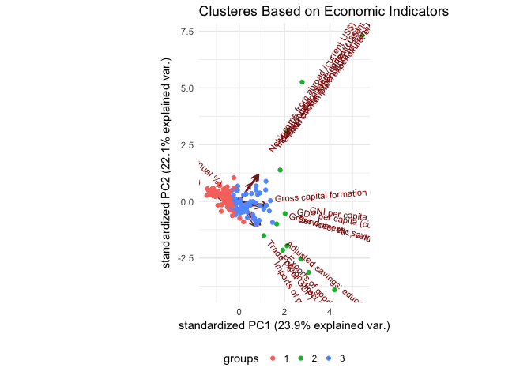

```r
pca = prcomp(numericData, center = T, scale = T)
ggbiplot(pca,
         groups = as.factor(kcl$cluster)) +
  labs(title = "Clusteres Based on Economic Indicators")
```

۸. با استفاده از داده روشی برای پیش بینی رشد اقتصادی ایران در سال آینده ارائه دهید.

با استفاده از شاخص‌های هر سال، سعی می‌کنیم با استفاده از یک مدل خطی رشد اقتصادی سال بعد را پیشبینی کنیم. ابتدا سعی می‌کنیم با همان ۲۰ شاخصی که برای خوشه بندی استفاده کردیم اما خیلی از شاخص‌ها significant نمی‌شوند. برای همین تعدادی از آن‌ها را حذف می‌کنیم و با اندکی تغییر به شاخص‌هایی که در جدول آمده‌اند می‌رسیم. می‌بینیم که نتیجه خیلی هم بد نیست.

```r
library(h2o)
# h2o.init()

predictors = c(
  'BM.KLT.DINV.WD.GD.ZS',
  'GC.TAX.TOTL.GD.ZS',
  'BX.GSR.TOTL.CD',
  'NY.GNP.MKTP.KD',
  'NY.GDP.MKTP.KD.ZG',
  'BM.GSR.TOTL.CD'
)

predictorsInfo = series %>%
  filter(`Series Code` %in% predictors) %>%
  select(`Series Code`,`Indicator Name`)

kable(predictorsInfo, caption = "Model Predictors")
```

Model Predictors

| Series Code | Indicator Name |
| --- | --- |
| BM.GSR.TOTL.CD | Imports of goods, services and primary income (BoP, current US$) |
| BM.KLT.DINV.WD.GD.ZS | Foreign direct investment, net outflows (% of GDP) |
| BX.GSR.TOTL.CD | Exports of goods, services and primary income (BoP, current US$) |
| GC.TAX.TOTL.GD.ZS | Tax revenue (% of GDP) |
| NY.GDP.MKTP.KD.ZG | GDP growth (annual %) |
| NY.GNP.MKTP.KD | GNI (constant 2010 US$) |

```r
modelData = data %>%
  select(-X63, -`Indicator Name`, -`Country Code`) %>%
  filter(`Indicator Code`%in% c(predictors, 'NY.GDP.MKTP.KD.ZG')) %>%
  filter(`Country Name` == 'Iran, Islamic Rep.') %>%
  gather(key = 'year', value = 'value', `1960`:`2017`) %>%
  spread('Indicator Code', 'value') %>%
  arrange(year) %>%
  mutate(result = lead(`NY.GDP.MKTP.KD.ZG`)) %>%
  select(- `Country Name`, - year) %>%
  drop_na() %>%
  as.data.frame()

model = h2o.glm(y = "result", x = setdiff(colnames(modelData), "result"),
        training_frame = as.h2o(modelData),
        family = "gaussian")
h2o.mse(model)
```

```
## [1] 4.316019
```

۹. سوالهای ۵ تا ۷ را ابتدا برای ۲۰ شاخص سلامت سپس بر حسب ۲۰ شاخص آموزشی تکرار کنید.

مشابه سوالات قبل عمل می‌کنیم. نتایج را در زیر می‌بینید:

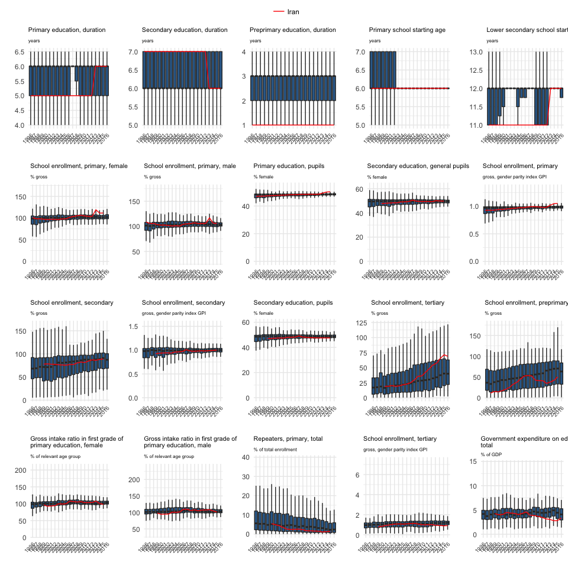

```r
availability.education = availability %>% filter(str_detect(Topic, "Education"))

educationIndicators = c(
  'SE.PRM.DURS',
  'SE.SEC.DURS',
  'SE.PRE.DURS',
  'SE.PRM.AGES',
  'SE.SEC.AGES',
  'SE.PRM.ENRR.FE',
  'SE.PRM.ENRR.MA',
  'SE.PRM.ENRL.FE.ZS',
  'SE.SEC.ENRL.GC.FE.ZS',
  'SE.ENR.PRIM.FM.ZS',
  'SE.SEC.ENRR',
  'SE.ENR.SECO.FM.ZS',
  'SE.SEC.ENRL.FE.ZS',
  'SE.TER.ENRR',
  'SE.PRE.ENRR',
  'SE.PRM.GINT.FE.ZS',
  'SE.PRM.GINT.MA.ZS',
  'SE.PRM.REPT.ZS',
  'SE.ENR.TERT.FM.ZS',
  'SE.XPD.TOTL.GD.ZS'
)


plots = list()
for(i in 1:length(educationIndicators)) {
  code = educationIndicators[i]
  name = series %>% filter(`Series Code` == code) %>%
    .$`Indicator Name` %>%
    str_extract("^[^\\(]*(?=\\()") %>%
    str_wrap(width = 40)

  sub = series %>% filter(`Series Code` == code) %>%
    .$`Indicator Name` %>%
    str_extract("\\(.*$") %>%
    str_replace_all("\\(", "") %>%
    str_replace_all("\\)", "")
  plotData = data %>%
    filter(`Indicator Code` == code) %>%
    select(-`Indicator Name`, -`Indicator Code`, -X63) %>%
    gather('year', 'value', `1960`:`2016`) %>%
    filter(year >= 1996)

  iranData = plotData %>%
    filter(`Country Name`== 'Iran, Islamic Rep.')

  yLimits = numeric(2)
  yLimits[1] = min(quantile(plotData$value, c(0.1, 0.9), na.rm = T)[1], min(iranData$value))
  yLimits[2] = max(quantile(plotData$value, c(0.1, 0.9), na.rm = T)[2], max(iranData$value))

  plots[[i]] = ggplot() +
    geom_boxplot(data = plotData, aes(x = year, y = value, fill = 1), outlier.shape = NA) +
    geom_line(data= iranData, aes(x = year, y = value, group = 1, color = "red")) +
    ylim(yLimits) +
    labs(title = name, y = "", x = "", subtitle = sub) +
    scale_color_manual(labels = 'Iran', values = 'red') +
    guides(fill = F) +
    theme(legend.title=element_blank()) +
    theme(plot.title = element_text(size=8), plot.subtitle = element_text(size=6)) +
    theme(axis.text.x = element_text(angle = 45, hjust = 1, size = 7))
}

ggarrange(plotlist = plots, common.legend = T)
```

```r
recentData = data %>% select(-X63) %>% filter(`Indicator Code` %in% educationIndicators) %>%
    gather("year", "value", `1960`:`2017`) %>% drop_na() %>% mutate(year = as.numeric(year)) %>%
    arrange(year) %>% group_by(`Country Name`, `Indicator Name`) %>% summarise(lastValue = last(value)) %>%
    spread("Indicator Name", "lastValue") %>% drop_na()

numericData = recentData[, -1] %>% scale()
kcl = kmeans(numericData, centers = 3)
results = data.frame(country = recentData$`Country Name`, cluster = kcl$cluster,
    stringsAsFactors = F)

for (i in 1:3) {
    clusterCountries = results %>% filter(cluster == i) %>% .$country
    cat("\n\nCluster No.", i, ":\n")
    cat(clusterCountries, sep = ", ")
}
```

```
##
##
## Cluster No. 1 :
## Afghanistan, Angola, Benin, Burundi, Cambodia, Cameroon, Central African Republic, Chad, Congo, Dem. Rep., Cote d'Ivoire, Ethiopia, Gabon, Guinea, Guinea-Bissau, Iraq, Liberia, Madagascar, Malawi, Mali, Mozambique, Niger, Pakistan, Sierra Leone, Togo, Uganda, Yemen, Rep., Zambia
##
## Cluster No. 2 :
## Antigua and Barbuda, Aruba, Bahamas, The, Belize, Bermuda, Bhutan, Botswana, Burkina Faso, Cabo Verde, Comoros, Congo, Rep., Costa Rica, Cuba, Djibouti, Dominica, Dominican Republic, Egypt, Arab Rep., El Salvador, Equatorial Guinea, Eritrea, Fiji, Gambia, The, Ghana, Grenada, Guatemala, Guyana, H…
##
## Cluster No. 3 :
## Albania, Algeria, Argentina, Armenia, Austria, Azerbaijan, Bahrain, Bangladesh, Belarus, Belgium, Brazil, Brunei Darussalam, Bulgaria, Canada, Chile, China, Colombia, Croatia, Cyprus, Czech Republic, Denmark, Ecuador, Estonia, Finland, France, Georgia, Germany, Greece, Hong Kong SAR, China, Hunga…
```

```r
iranClusterNo = results$cluster[results$country == "Iran, Islamic Rep."]
paste("Iran is in cluster no.", iranClusterNo)
```

```
## [1] "Iran is in cluster no. 2"
```

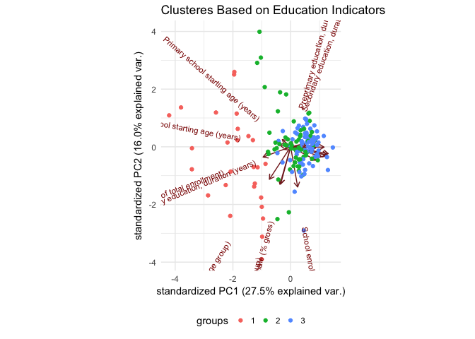

```r
pca = prcomp(numericData, center = T, scale = T)
ggbiplot(pca,
         groups = as.factor(kcl$cluster))+
  labs(title = "Clusteres Based on Education Indicators")
```

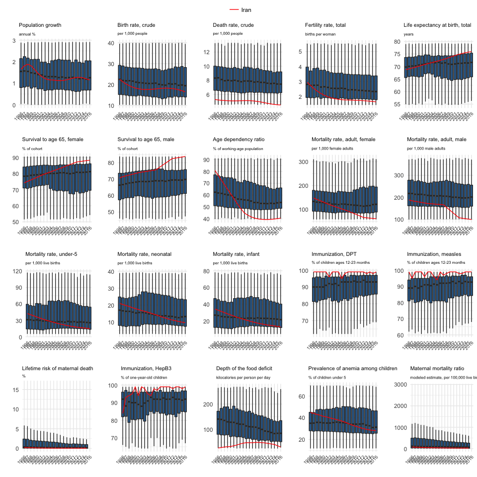

```r
availability.health = availability %>% filter(str_detect(Topic, "Health"))

healthIndicators = c(
  'SP.POP.GROW',
  'SP.DYN.CBRT.IN',
  'SP.DYN.CDRT.IN',
  'SP.DYN.TFRT.IN',
  'SP.DYN.LE00.IN',
  'SP.DYN.TO65.FE.ZS',
  'SP.DYN.TO65.MA.ZS',
  'SP.POP.DPND',
  'SP.DYN.AMRT.FE',
  'SP.DYN.AMRT.MA',
  'SH.DYN.MORT',
  'SH.DYN.NMRT',
  'SP.DYN.IMRT.IN',
  'SH.IMM.IDPT',
  'SH.IMM.MEAS',
  'SH.MMR.RISK.ZS',
  'SH.IMM.HEPB',
  'SN.ITK.DFCT',
  'SH.ANM.CHLD.ZS',
  'SH.STA.MMRT'
)

plots = list()
for(i in 1:length(healthIndicators)) {
  code = healthIndicators[i]
  name = series %>% filter(`Series Code` == code) %>%
    .$`Indicator Name` %>%
    str_extract("^[^\\(]*(?=\\()")
  sub = series %>% filter(`Series Code` == code) %>%
    .$`Indicator Name` %>%
    str_extract("\\(.*$") %>%
    str_replace_all("\\(", "") %>%
    str_replace_all("\\)", "")
  plotData = data %>%
    filter(`Indicator Code` == code) %>%
    select(-`Indicator Name`, -`Indicator Code`, -X63) %>%
    gather('year', 'value', `1960`:`2016`) %>%
    filter(year >= 1996)

  iranData = plotData %>%
    filter(`Country Name`== 'Iran, Islamic Rep.')

  yLimits = numeric(2)
  yLimits[1] = min(quantile(plotData$value, c(0.1, 0.9), na.rm = T)[1], min(iranData$value))
  yLimits[2] = max(quantile(plotData$value, c(0.1, 0.9), na.rm = T)[2], max(iranData$value))

  plots[[i]] = ggplot() +
    geom_boxplot(data = plotData, aes(x = year, y = value, fill = 1), outlier.shape = NA) +
    geom_line(data= iranData, aes(x = year, y = value, group = 1, color = "red")) +
    ylim(yLimits) +
    labs(title = name, y = "", x = "", subtitle = sub) +
    scale_color_manual(labels = 'Iran', values = 'red') +
    guides(fill = F) +
    theme(legend.title=element_blank()) +
    theme(plot.title = element_text(size=8), plot.subtitle = element_text(size=6)) +
    theme(axis.text.x = element_text(angle = 45, hjust = 1, size = 7))
}

ggarrange(plotlist = plots, common.legend = T)
```

```r
recentData = data %>% select(-X63) %>% filter(`Indicator Code` %in% healthIndicators) %>%
    gather("year", "value", `1960`:`2017`) %>% drop_na() %>% mutate(year = as.numeric(year)) %>%
    arrange(year) %>% group_by(`Country Name`, `Indicator Name`) %>% summarise(lastValue = last(value)) %>%
    spread("Indicator Name", "lastValue") %>% drop_na()

numericData = recentData[, -1] %>% scale()
kcl = kmeans(numericData, centers = 3)
results = data.frame(country = recentData$`Country Name`, cluster = kcl$cluster,
    stringsAsFactors = F)

for (i in 1:3) {
    clusterCountries = results %>% filter(cluster == i) %>% .$country
    cat("\n\nCluster No.", i, ":\n")
    cat(clusterCountries, sep = ", ")
}
```

```
##
##
## Cluster No. 1 :
## Algeria, Argentina, Armenia, Azerbaijan, Bangladesh, Barbados, Belize, Brazil, Brunei Darussalam, Cabo Verde, Caribbean small states, Chile, China, Colombia, Costa Rica, Cuba, East Asia & Pacific, East Asia & Pacific (excluding high income), East Asia & Pacific (IDA & IBRD countries), Ecuador, Eg…
##
## Cluster No. 2 :
## Afghanistan, Angola, Benin, Burkina Faso, Cameroon, Central African Republic, Chad, Congo, Rep., Cote d'Ivoire, Ethiopia, Fragile and conflict affected situations, Gambia, The, Guinea, Guinea-Bissau, Haiti, Heavily indebted poor countries (HIPC), IDA blend, IDA only, IDA total, Least developed co…
##
## Cluster No. 3 :
## Arab World, Bolivia, Botswana, Cambodia, Djibouti, Dominican Republic, Early-demographic dividend, Gabon, Ghana, Guatemala, Guyana, IDA & IBRD total, India, Indonesia, Iraq, Kenya, Kiribati, Lao PDR, Low & middle income, Lower middle income, Madagascar, Middle income, Myanmar, Namibia, Nepal, Oth…
```

```r
iranClusterNo = results$cluster[results$country == "Iran, Islamic Rep."]
paste("Iran is in cluster no.", iranClusterNo)
```

```
## [1] "Iran is in cluster no. 1"
```

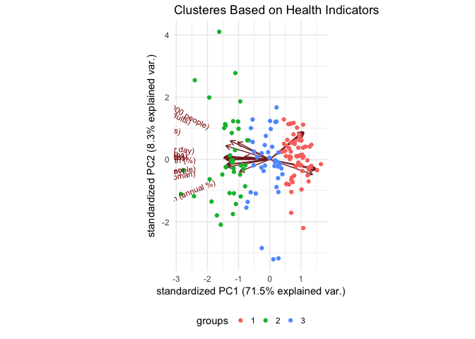

```r
pca = prcomp(numericData, center = T, scale = T)
ggbiplot(pca,
         groups = as.factor(kcl$cluster))+
  labs(title = "Clusteres Based on Health Indicators")
```

۱۰. کشورهای دنیا را بر حسب ۶۰ شاخص اقتصادی، سلامت و آموزش با روش سلسله مراتبی خوشه بندی کرده و دندروگرام آن را رسم نمایید. اگر داده ها بر سه دسته تقسیم شوند ایران در کدام دسته می گنجد؟

نتایج را در زیر می بینید:

```r
clusterData = data %>% select(-X63) %>% filter(`Indicator Code` %in% c(economicIndicators,
    healthIndicators, educationIndicators)) %>% gather("year", "value", `1960`:`2017`) %>%
    drop_na() %>% mutate(year = as.numeric(year)) %>% arrange(year) %>% group_by(`Country Name`,
    `Indicator Name`) %>% summarise(lastValue = last(value)) %>% spread("Indicator Name",
    "lastValue") %>% drop_na() %>% as.data.frame()

rownames(clusterData) = clusterData$`Country Name`
clusterData = clusterData[, -1] %>% scale()

dist = stats::dist(clusterData, method = "euclidean")
clus = hclust(dist, method = "complete")
hcut = cutree(clus, k = 3)
results = data.frame(country = rownames(clusterData), cluster = hcut, stringsAsFactors = F)

for (i in 1:3) {
    clusterCountries = results %>% filter(cluster == i) %>% .$country
    cat("\n\nCluster No.", i, ":\n")
    cat(clusterCountries, sep = ", ")
}
```

```
##
##
## Cluster No. 1 :
## Afghanistan, Angola, Benin, Cameroon, Central African Republic, Chad, Cote d'Ivoire, Guinea, Guinea-Bissau, Liberia, Mali, Niger, Pakistan, Sierra Leone, Togo, Yemen, Rep.
##
## Cluster No. 2 :
## Algeria, Argentina, Armenia, Azerbaijan, Bangladesh, Belize, Botswana, Brazil, Brunei Darussalam, Burkina Faso, Cabo Verde, Cambodia, Chile, Colombia, Congo, Rep., Costa Rica, Djibouti, Dominican Republic, Ecuador, Egypt, Arab Rep., El Salvador, Ethiopia, Fiji, Gabon, Gambia, The, Georgia, Ghana,…
##
## Cluster No. 3 :
## China
```

```r
iranClusterNo = results %>% filter(country == "Iran, Islamic Rep.") %>% .$cluster
paste("Iran is in cluster no.", iranClusterNo)
```

```
## [1] "Iran is in cluster no. 2"
```

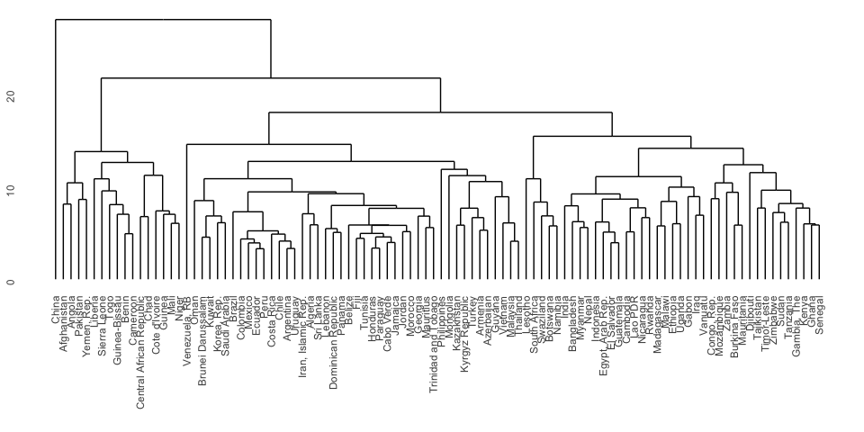

```r
library(ggdendro)
ggdendrogram(clus, size = 0.5)
```

۱۱. سه یافته جالب از داده ها استخراج کنید.

جوانی جمعیت باعث افزایش رشد اقتصادی نمی‌شود.

بسیار می‌شنویم که جمعیت کشور در حال پیر شدن است و این در رشد اقتصاد ما موثر خواهد بود و باید با افزایش جمعیت با آن مقابله کرد. برای همین تلاش کردیم بررسی کنیم آیا کشورهایی که جوان‌تر هستند (جمعیت با سن بین ۱۵ تا ۶۵ سال درصد بیشتری از کل هستند) آیا رشد اقتصادی بیشتری دارند یا نه. با استفاده از تست کوریلشن روش spearman این ادعا را بررسی کردیم. به نظر می‌رسد با این داده نمی‌توان مستقل بودن این دو کمیت را رد کرد.

```r
GDP.growth_Young.pop = data %>%
  select(-X63) %>%
  filter(`Indicator Code` %in% c('NY.GDP.MKTP.KD.ZG', 'SP.POP.1564.TO.ZS')) %>%
  gather("year", "value", `1960`:`2017`) %>%
  drop_na() %>%
  mutate(year = as.numeric(year)) %>%
  arrange(year) %>%
  group_by(`Country Name`, `Indicator Code`) %>%
  summarise(lastValue = last(value)) %>%
  spread("Indicator Code", "lastValue") %>%
  rename(country = `Country Name`, youngPop = `SP.POP.1564.TO.ZS`, gdpGrowth = `NY.GDP.MKTP.KD.ZG`) %>%
  mutate(youngPop = round(youngPop, 2), gdpGrowth = round(gdpGrowth, 2)) %>%
  filter(country != "Libya") %>%
  left_join(eco.clus.results) %>%
  mutate(type = ifelse(cluster == 1, 'Undeveloped', 'Developed')) %>%
  drop_na()


hchart(GDP.growth_Young.pop, type = "scatter",
       hcaes(x = youngPop, y = gdpGrowth, group = type, name = type)) %>%
  hc_tooltip(pointFormat = "<b> {point.country} </b> <br/>
             Young Population: {point.youngPop} <br/>
             GDP growth: {point.gdpGrowth} <br/>") %>%
  hc_xAxis(title = list(text = "Population ages 15-64 (% of total)")) %>%
  hc_yAxis(title = list(text = "GDP growth"))
```

[interactive chart not shown]

```r
cor.test(GDP.growth_Young.pop$gdpGrowth, GDP.growth_Young.pop$youngPop,
         method = "spearman",
         alternative = "greater")
```

```
##
##  Spearman's rank correlation rho
##
## data:  GDP.growth_Young.pop$gdpGrowth and GDP.growth_Young.pop$youngPop
## S = 811320, p-value = 0.9826
## alternative hypothesis: true rho is greater than 0
## sample estimates:
##        rho
## -0.1664903
```

کشورهایی که در کاهش انتشار گازهای گلخانه‌ایشان تلاش می‌کنند رشد اقتصادی کمتری دارند.

دو کمیت میزان تغییر انتشار گازهای گلخانه‌ای نسبت به سال ۱۹۹۰ و رشد اقتصادی را با تست کوریلیشن spearman مقایسه کردیم. به نظر می‌رسد رابطه‌ی مستقیمی بین این دو کمیت برقرار است.

```r
GDP.growth_GH.decrease = data %>%
  select(-X63) %>%
  filter(`Indicator Code` %in% c('NY.GDP.MKTP.KD.ZG', 'EN.ATM.GHGT.ZG')) %>%
  gather("year", "value", `1960`:`2017`) %>%
  drop_na() %>%
  mutate(year = as.numeric(year)) %>%
  arrange(year) %>%
  group_by(`Country Name`, `Indicator Code`) %>%
  summarise(lastValue = last(value)) %>%
  spread("Indicator Code", "lastValue") %>%
  rename(country = `Country Name`, ghDecrease = `EN.ATM.GHGT.ZG`, gdpGrowth = `NY.GDP.MKTP.KD.ZG`) %>%
  mutate(ghDecrease = round(ghDecrease, 2), gdpGrowth = round(gdpGrowth, 2)) %>%
  filter(!country %in% c("Equatorial Guinea", "Libya")) %>%
  drop_na()

hchart(GDP.growth_GH.decrease, type = "scatter",regression = T,
       hcaes(x = ghDecrease, y = gdpGrowth)) %>%
  hc_tooltip(pointFormat = "
             <b> {point.country} </b> <br/>
             Greenhouse Emission Change: {point.ghDecrease} <br/>
             GDP growth: {point.gdpGrowth} <br/>") %>%
  hc_xAxis(title = list(text = "Greenhouse Gas Emission Change Since 1990 (%)")) %>%
  hc_yAxis(title = list(text = "GDP growth"))
```

[interactive chart not shown]

```r
cor.test(GDP.growth_GH.decrease$gdpGrowth, GDP.growth_GH.decrease$ghDecrease,
         method = "spearman")
```

```
##
##  Spearman's rank correlation rho
##
## data:  GDP.growth_GH.decrease$gdpGrowth and GDP.growth_GH.decrease$ghDecrease
## S = 1597000, p-value = 0.002117
## alternative hypothesis: true rho is not equal to 0
## sample estimates:
##       rho
## 0.2020958
```

کشورهای مهاجرپذیر از کشورهای مهاجر رشد اقتصادی کمتری دارند.

انتظار داریم کشورهایی که مردم آن‌ها به خارج مهاجرت می‌کنند در شرایط بدتری باشند و رشد اقتصادی مناسبی نداشته باشند. اما بر خلاف انتظار اینطور نیست!! کشورهایی که مردم آن‌ها مهاجرت می‌کنند رشد اقتصادی بیشتری دارند! برای بررسی این موضوع از شاخص net migration و رشد اقتصادی استفاده می‌کنیم. نتیجه آنقدر شگفت آور بود که فکر کردیم شاخص net migration را اشتباه برداشت کرده‌ایم. برای همین برای بررسی کشورهای سوریه، آلمان و آمریکا رو بررسی کردیم که وضعیت آن‌ها را می‌دانیم. می‌بینیم که اشتباهی رخ نداده و نتیجه واقعیت دارد.

```r
GDPgrowthMigration = data %>%
  select(-X63) %>%
  filter(`Indicator Code` %in% c('NY.GDP.MKTP.KD.ZG', 'SM.POP.NETM')) %>%
  gather("year", "value", `1960`:`2017`) %>%
  drop_na() %>%
  mutate(year = as.numeric(year)) %>%
  arrange(year) %>%
  group_by(`Country Name`, `Indicator Code`) %>%
  summarise(lastValue = last(value)) %>%
  spread("Indicator Code", "lastValue") %>%
  rename(country = `Country Name`, gdpGrowth = `NY.GDP.MKTP.KD.ZG`, migration = `SM.POP.NETM`) %>%
  mutate(gdpGrowth = round(gdpGrowth), migration = ifelse(migration > 0, "receiver", "Sender")) %>%
  drop_na()

senders = GDPgrowthMigration %>% filter(migration == "Sender") %>% .$gdpGrowth
receivers = GDPgrowthMigration %>% filter(migration == "receiver") %>% .$gdpGrowth
wilcox.test(senders, receivers)
```

```
##
##  Wilcoxon rank sum test with continuity correction
##
## data:  senders and receivers
## W = 8429.5, p-value = 0.0002444
## alternative hypothesis: true location shift is not equal to 0
```

```r
paste("Senders Avg. GDP growth:", mean(senders))
```

```
## [1] "Senders Avg. GDP growth: 2.8476821192053"
```

```r
paste("Receivers Avg. GDP growth:", mean(receivers))
```

```
## [1] "Receivers Avg. GDP growth: 1.95402298850575"
```

```r
GDPgrowthMigration %>%
  select(country, migration) %>%
  filter(country %in% c('Syrian Arab Republic', 'Germany', 'United States')) %>%
  kable(caption = "Some Of GDP growth vs. net immigration data")
```

Some Of GDP growth vs. net immigration data

| country | migration |
| --- | --- |
| Germany | receiver |
| Syrian Arab Republic | Sender |
| United States | receiver |